# Heart Miniproject

Ruben Lancaster

2024-03-04

## Data Description

The dataset contains information on patients diagnosed with heart disease. There are 303 total patients. 6 patients had missing information and were therefore removed from the dataset, since statistical learning models can’t handle missing values (another option would be imputing missing values, but I didn’t do that here.)

Of the 297 remaining patients, 137 were diagnosed with heart disease and 160 did not have a diagnosis of heart disease. 96 of the patients were female, and 201 were male.

The following table describes the predictor variables.

| Variable Name | Description |
| --- | --- |
| Age | Age in years |
| Sex | (1) male, (0) = female |
| ChestPain | chest pain type (1) typical angina, (2) atypical angina (3) non-anginal pain, (4) asymptomatic (categorical) |
| RestBP | Resting blood pressure (in mm Hg on admission to the hospital) |
| Fbs | Fasting blood sugar more than 120 mg/dl? (0) Fasting blood sugar less than 120 mg/dl, (1) fasting blood sugar more than 120 mg/dl |
| RestECG | Resting electrocardiographic results: (0) normal, (1) having ST-T wave abnormality, (2) showing probable or definite left ventricular hypertrophy by Estes’ criteria |
| MaxHR | Maximum heart rate achieved |
| ExAng | Exercise induced angina? |
| Oldpeak | ST depression induced by exercise relative to rest |
| Slope | The slope of the peak exercise ST segment: (1) upsloping, (2) flat, (3) downsloping |
| Ca | Number of major vessels (0-3) colored by flourosopy |
| Thal | (3) normal, (6) fixed defect, (7) reversable defect class |

A diagnosis of heart disease was the response variable, or what I am trying to predict.

| Variable Name | Description |
| --- | --- |
| AHD | Diagonosis of heart disease (1 = Yes, 0 = No) |

Below are density plots for each numeric predictor variable, colored by AHD status. Some variables, like Age, have a more pronounced difference than others, like RestBP. It will be interesting to see if these variables are the ones the elastic net identifies as a variable of greater effect.

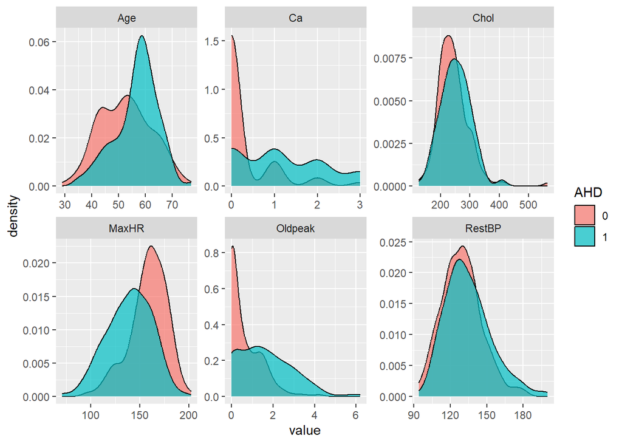

Below are density plots for each categorical predictor variable, colored by AHD status. All of these variables seem to sway one way or another with distribution of AHD status except for Fbs, where the difference between AHD status is minimal.

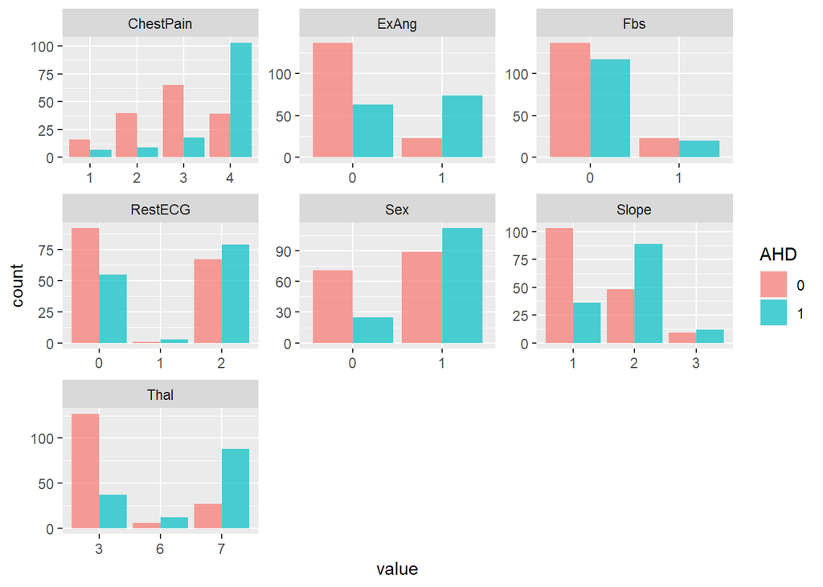

Here is a summary of the 7 categorical and 6 numeric predictor variables I am working with:

| Variable Name | Variable Type |
| --- | --- |
| Sex | Categorical |
| ChestPain | Categorical |
| Fbs | Categorical |
| RestECG | Categorical |
| ExAng | Categorical |
| Slope | Categorical |
| Thal | Categorical |
| Age | Numeric |
| RestBP | Numeric |
| Chol | Numeric |
| MaxHR | Numeric |
| Oldpeak | Numeric |
| Ca | Numeric |
| AHD | Numeric |

Since I’m dealing with a mix of categorical and numeric predictor variables and the response is categorical, I chose the following models as options:

| Model name | Description | Tuning parameters | Engine |
| --- | --- | --- | --- |
| logistic_reg | Logistic regression with an elastic net, mixture of LASSO and Ridge Regression | penalty, mixture | glmnet |
| naive_Bayes | Naive Bayes | smoothness, Laplace | klaR |
| rand_forest | Random Forest | trees | randomForest |
| svm_rbf | Support Vector Machine model with radial basis function | cost | kernlab |
| svm_poly | Support Vector Machine model with polynomial support | cost | kernlab |

Data were preprocessed by centering/scaling and adding dummy variables before use with the elastic net and SVM models, which require scaled numeric input.

I chose to split my data into 7 folds, resulting in splits of about n = 200 for training and n = 30 for testing at each split.

## Results

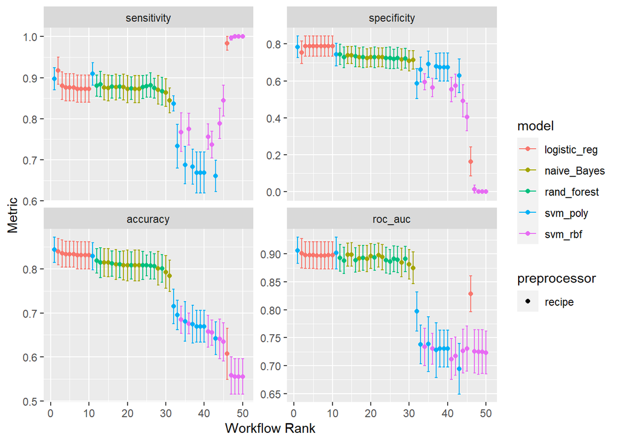

The results of cross-validation are shown above. An SVM polynomial model performs the best, followed closely by elastic logistic models (a mixture between LASSO and ridge regression). SVM rbf models consistently perform the worst, so I will only include SVM poly models from here.  
Accuracy and ROC_AUC metrics for how these models are expected to perform on unseen data are shown below. The model with the highest accuracy when tested with unseen data is the logistic regression with elastic net mixture.

[output not shown]

The accuracy for the logistic regression with an elastic net mixture model was 0.869. The predictive ability of a model can be illustrated with a confidence matrix, and four of the models are shown below.

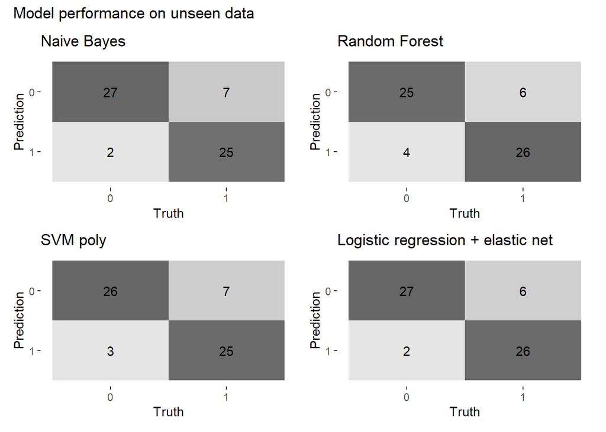

Confidence matrices for four best performing models

ROC curves illustrate the sensitivity and specificity of a model. The larger the area under the curve (AUC), the better specificity and sensitivity a model is able to achieve. The largest ROC AUC value is for the logistic regression with elastic net mixture, at 0.946.

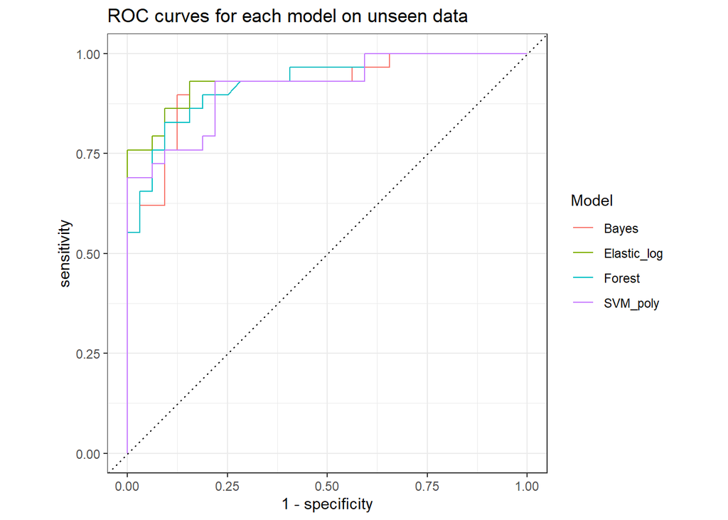

Receiver-Operator Characteristic curves for the four best performing models

I would recommend this logistic regression with elastic net mixture model out of the five models tested here for predicting new data, with an accuracy of about 87%.

Coefficient estimates identified by the elastic model for predictors are shown below. 0 values indicate that the variables are not highly predictive and have been removed from the model. Elastic nets are helpful for reducing the potential of overfitting, which can occur when there are many predictor variables.

| term | estimate |
| --- | --- |
| (Intercept) | -1.2977347 |
| Age | 0.0000000 |
| RestBP | 0.0053052 |
| Chol | 0.0000000 |
| MaxHR | -0.0093374 |
| Oldpeak | 0.3125504 |
| Ca | 0.5570750 |
| Sex_X1 | 0.2582515 |
| ChestPain_X2 | 0.0000000 |
| ChestPain_X3 | -0.0448518 |
| ChestPain_X4 | 0.6823192 |
| Fbs_X1 | 0.0000000 |
| RestECG_X1 | 0.0000000 |
| RestECG_X2 | 0.0000000 |
| ExAng_X1 | 0.3085063 |
| Slope_X2 | 0.3358580 |
| Slope_X3 | 0.0000000 |
| Thal_X6 | 0.0000000 |
| Thal_X7 | 0.8237717 |

A summary of the variables and their predictive ability is shown below. Log odds predictive ability for dummy variables is noted as “variable vs reference category (trend),” where trend is the the predictive trend for the variable compared to the reference category.

| Predictor | Type | Category and/or trend |
| --- | --- | --- |
| RestBP | Quantitative | Positive |
| MaxHR | Quantitative | Negative |
| Oldpeak | Quantitative | Positive |
| Ca | Quantitative | Positive |
| Sex | Categorical | Male vs female (positive) |
| ChestPain | Categorical | Non-anginal pain vs typical angina (negative) and asymptomatic pain vs typical angina (positive) |
| ExAng | Categorical | Exercise induced angina vs no exercise induced angina (positive) |
| Slope | Categorical | flat vs upsloping (positive) |
| Thal | Categorical | Reversable defect class vs normal (positive) |

## References

https://workflowsets.tidymodels.org/articles/tuning-and-comparing-models.html  
https://www.tmwr.org/workflow-sets  
https://www.youtube.com/watch?v=5LvTiy9dqrI